# Global Monkeypox Outbreak Dynamics: A Multi-faceted Predictive Analysis and Risk Assessment Framework

Gaurav Dnyanesh Mahajan

```python
# import packages
import numpy as np
import pandas as pd
import seaborn as sns
import matplotlib.pyplot as plt
```

```python
# data collection
df=pd.read_csv('monkeypox.csv')
df
```

|  | location | date | iso_code | total_cases | total_deaths | new_cases | new_deaths | new_cases_smoothed | new_deaths_smoothed | new_cases_per_million | total_cases_per_million | new_cases_smoothed_per_million | new_deaths_per_million | total_deaths_per_million | new_deaths_smoothed_per_million |
| --- | --- | --- | --- | --- | --- | --- | --- | --- | --- | --- | --- | --- | --- | --- | --- |
| 0 | Africa | 2022-05-01 | NaN | 42.0 | 2.0 | 2.0 | 0.0 | 0.29 | 0.0 | 0.001 | 0.030 | 0.000 | 0.0 | 0.00141 | 0.0 |
| 1 | Africa | 2022-05-02 | NaN | 42.0 | 2.0 | 0.0 | 0.0 | 0.29 | 0.0 | 0.000 | 0.030 | 0.000 | 0.0 | 0.00141 | 0.0 |
| 2 | Africa | 2022-05-03 | NaN | 42.0 | 2.0 | 0.0 | 0.0 | 0.29 | 0.0 | 0.000 | 0.030 | 0.000 | 0.0 | 0.00141 | 0.0 |
| 3 | Africa | 2022-05-04 | NaN | 42.0 | 2.0 | 0.0 | 0.0 | 0.29 | 0.0 | 0.000 | 0.030 | 0.000 | 0.0 | 0.00141 | 0.0 |
| 4 | Africa | 2022-05-05 | NaN | 42.0 | 2.0 | 0.0 | 0.0 | 0.29 | 0.0 | 0.000 | 0.030 | 0.000 | 0.0 | 0.00141 | 0.0 |
| ... | ... | ... | ... | ... | ... | ... | ... | ... | ... | ... | ... | ... | ... | ... | ... |
| 79040 | World | 2024-07-24 | NaN | 99352.0 | 208.0 | 0.0 | 0.0 | 3.86 | 0.0 | 0.000 | 12.230 | 0.000 | 0.0 | 0.02560 | 0.0 |
| 79041 | World | 2024-07-25 | NaN | 99352.0 | 208.0 | 0.0 | 0.0 | 3.86 | 0.0 | 0.000 | 12.230 | 0.000 | 0.0 | 0.02560 | 0.0 |
| 79042 | World | 2024-07-26 | NaN | 99352.0 | 208.0 | 0.0 | 0.0 | 3.86 | 0.0 | 0.000 | 12.230 | 0.000 | 0.0 | 0.02560 | 0.0 |
| 79043 | World | 2024-07-27 | NaN | 99373.0 | 208.0 | 21.0 | 0.0 | 6.86 | 0.0 | 0.003 | 12.232 | 0.001 | 0.0 | 0.02560 | 0.0 |
| 79044 | World | 2024-07-28 | NaN | 99388.0 | 208.0 | 15.0 | 0.0 | 8.14 | 0.0 | 0.002 | 12.234 | 0.001 | 0.0 | 0.02560 | 0.0 |

79045 rows × 15 columns

```python
# Displaying information
df.info()
```

```
<class 'pandas.core.frame.DataFrame'>
RangeIndex: 79045 entries, 0 to 79044
Data columns (total 15 columns):
 #   Column                           Non-Null Count  Dtype
---  ------                           --------------  -----
 0   location                         79045 non-null  object
 1   date                             79045 non-null  object
 2   iso_code                         73455 non-null  object
 3   total_cases                      79033 non-null  float64
 4   total_deaths                     79033 non-null  float64
 5   new_cases                        79033 non-null  float64
 6   new_deaths                       79033 non-null  float64
 7   new_cases_smoothed               79033 non-null  float64
 8   new_deaths_smoothed              79033 non-null  float64
 9   new_cases_per_million            79033 non-null  float64
 10  total_cases_per_million          79033 non-null  float64
 11  new_cases_smoothed_per_million   79033 non-null  float64
 12  new_deaths_per_million           79033 non-null  float64
 13  total_deaths_per_million         79033 non-null  float64
 14  new_deaths_smoothed_per_million  79033 non-null  float64
dtypes: float64(12), object(3)
memory usage: 9.0+ MB
```

```python
# Check null values
df.isnull().sum()
```

```
location                              0
date                                  0
iso_code                           5590
total_cases                          12
total_deaths                         12
new_cases                            12
new_deaths                           12
new_cases_smoothed                   12
new_deaths_smoothed                  12
new_cases_per_million                12
total_cases_per_million              12
new_cases_smoothed_per_million       12
new_deaths_per_million               12
total_deaths_per_million             12
new_deaths_smoothed_per_million      12
dtype: int64
```

```python
# Fill missing numeric values with 0
df.fillna(0, inplace=True)

# Convert date column to datetime
df['date'] = pd.to_datetime(df['date'])
df.info()
```

```
<class 'pandas.core.frame.DataFrame'>
RangeIndex: 79045 entries, 0 to 79044
Data columns (total 15 columns):
 #   Column                           Non-Null Count  Dtype
---  ------                           --------------  -----
 0   location                         79045 non-null  object
 1   date                             79045 non-null  datetime64[ns]
 2   iso_code                         79045 non-null  object
 3   total_cases                      79045 non-null  float64
 4   total_deaths                     79045 non-null  float64
 5   new_cases                        79045 non-null  float64
 6   new_deaths                       79045 non-null  float64
 7   new_cases_smoothed               79045 non-null  float64
 8   new_deaths_smoothed              79045 non-null  float64
 9   new_cases_per_million            79045 non-null  float64
 10  total_cases_per_million          79045 non-null  float64
 11  new_cases_smoothed_per_million   79045 non-null  float64
 12  new_deaths_per_million           79045 non-null  float64
 13  total_deaths_per_million         79045 non-null  float64
 14  new_deaths_smoothed_per_million  79045 non-null  float64
dtypes: datetime64[ns](1), float64(12), object(2)
memory usage: 9.0+ MB
```

```python
# Check for any remaining missing values
print(df.isna().sum())
```

```
location                           0
date                               0
iso_code                           0
total_cases                        0
total_deaths                       0
new_cases                          0
new_deaths                         0
new_cases_smoothed                 0
new_deaths_smoothed                0
new_cases_per_million              0
total_cases_per_million            0
new_cases_smoothed_per_million     0
new_deaths_per_million             0
total_deaths_per_million           0
new_deaths_smoothed_per_million    0
dtype: int64
```

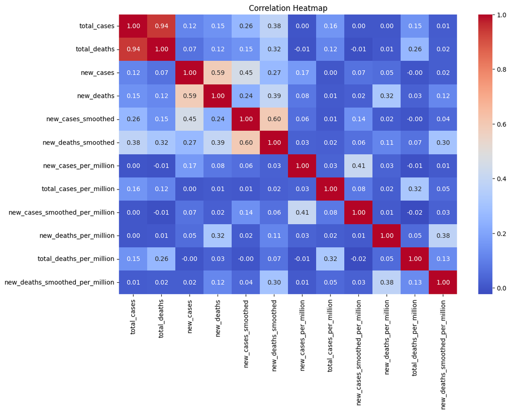

```python
# Select only numeric columns
numeric_df = df.select_dtypes(include=[np.number])

# Create a correlation heatmap
plt.figure(figsize=(12, 8))
sns.heatmap(numeric_df.corr(), annot=True, cmap='coolwarm', fmt='.2f')
plt.title('Correlation Heatmap')
plt.show()
```

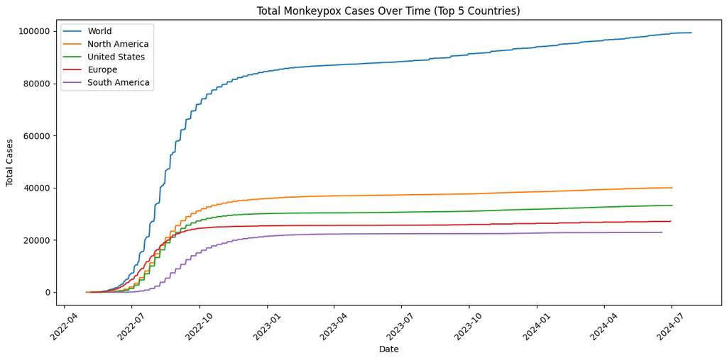

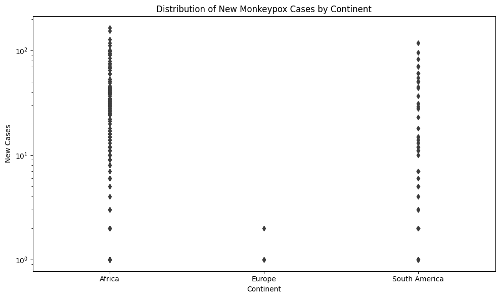

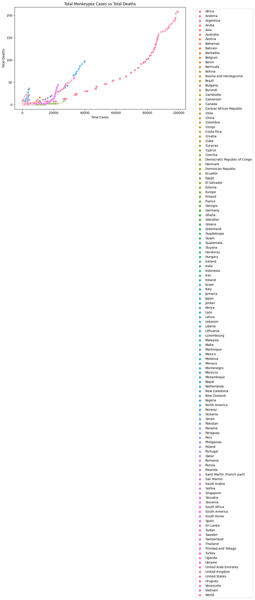

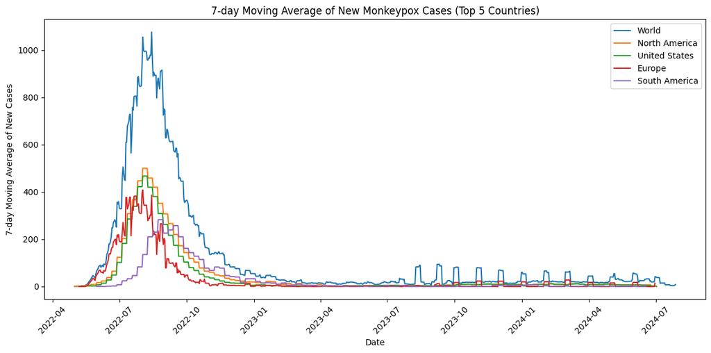

```python
# Time series plot of total cases for top 5 countries
top_5_countries = df.groupby('location')['total_cases'].max().sort_values(ascending=False).head(5).index
plt.figure(figsize=(12, 6))
for country in top_5_countries:
    country_data = df[df['location'] == country]
    plt.plot(country_data['date'], country_data['total_cases'], label=country)
plt.xlabel('Date')
plt.ylabel('Total Cases')
plt.title('Total Monkeypox Cases Over Time (Top 5 Countries)')
plt.legend()
plt.xticks(rotation=45)
plt.tight_layout()
plt.show()

# Box plot of new cases distribution by continent
df['continent'] = df['location'].map({'Africa': 'Africa', 'Andorra': 'Europe', 'Argentina': 'South America'})
plt.figure(figsize=(10, 6))
sns.boxplot(x='continent', y='new_cases', data=df)
plt.title('Distribution of New Monkeypox Cases by Continent')
plt.xlabel('Continent')
plt.ylabel('New Cases')
plt.yscale('log')  # Using log scale for better visualization
plt.tight_layout()
plt.show()

# Scatter plot of total cases vs total deaths
plt.figure(figsize=(10, 6))
sns.scatterplot(x='total_cases', y='total_deaths', hue='location', data=df)
plt.title('Total Monkeypox Cases vs Total Deaths')
plt.xlabel('Total Cases')
plt.ylabel('Total Deaths')
plt.legend(bbox_to_anchor=(1.05, 1), loc='upper left')
plt.tight_layout()
plt.show()

# Line plot of 7-day moving average of new cases
plt.figure(figsize=(12, 6))
for country in top_5_countries:
    country_data = df[df['location'] == country]
    plt.plot(country_data['date'], country_data['new_cases_smoothed'], label=country)
plt.xlabel('Date')
plt.ylabel('7-day Moving Average of New Cases')
plt.title('7-day Moving Average of New Monkeypox Cases (Top 5 Countries)')
plt.legend()
plt.xticks(rotation=45)
plt.tight_layout()
plt.show()
```

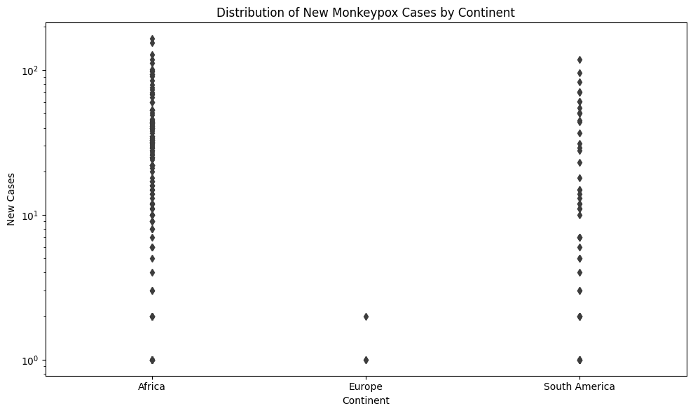

```python
# Box plot of new cases distribution by continent
df['continent'] = df['location'].map({'Africa': 'Africa', 'Andorra': 'Europe', 'Argentina': 'South America'})
plt.figure(figsize=(10, 6))
sns.boxplot(x='continent', y='new_cases', data=df)
plt.title('Distribution of New Monkeypox Cases by Continent')
plt.xlabel('Continent')
plt.ylabel('New Cases')
plt.yscale('log')  # Using log scale for better visualization
plt.tight_layout()
plt.show()
```

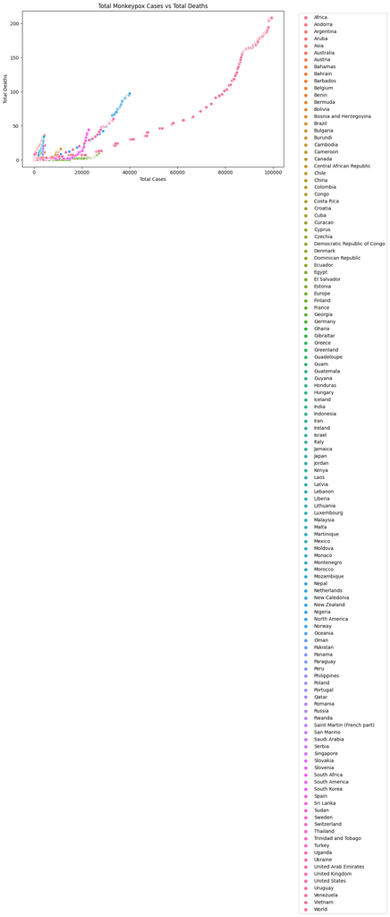

```python
# Scatter plot of total cases vs total deaths
plt.figure(figsize=(10, 6))
sns.scatterplot(x='total_cases', y='total_deaths', hue='location', data=df)
plt.title('Total Monkeypox Cases vs Total Deaths')
plt.xlabel('Total Cases')
plt.ylabel('Total Deaths')
plt.legend(bbox_to_anchor=(1.05, 1), loc='upper left')
plt.tight_layout()
plt.show()
```

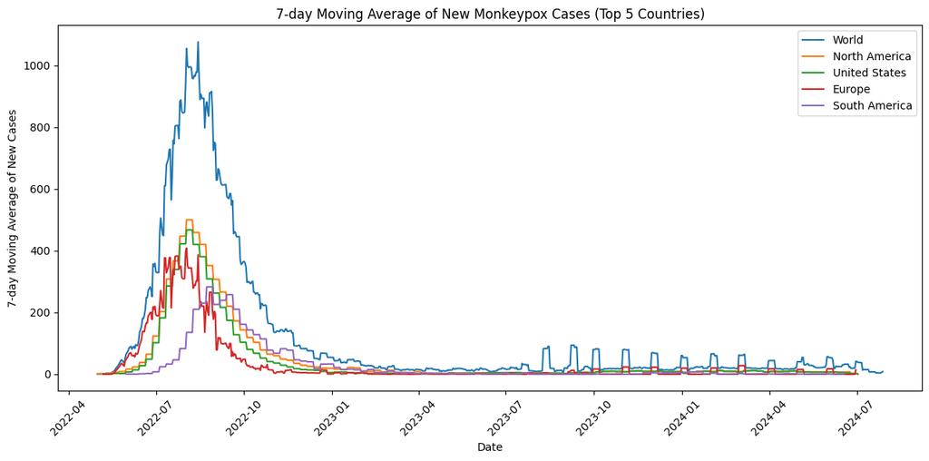

```python
# Line plot of 7-day moving average of new cases
plt.figure(figsize=(12, 6))
for country in top_5_countries:
    country_data = df[df['location'] == country]
    plt.plot(country_data['date'], country_data['new_cases_smoothed'], label=country)
plt.xlabel('Date')
plt.ylabel('7-day Moving Average of New Cases')
plt.title('7-day Moving Average of New Monkeypox Cases (Top 5 Countries)')
plt.legend()
plt.xticks(rotation=45)
plt.tight_layout()
plt.show()
```

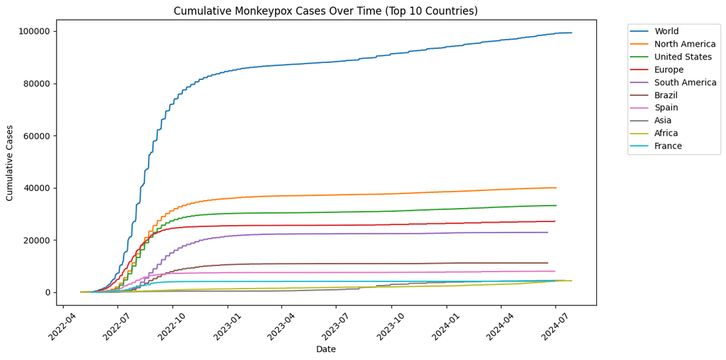

```python
# visualization of how monkeypox cases have accumulated over time in the top 10 most affected regions or countries.
top_10_countries = df.groupby('location')['total_cases'].max().nlargest(10).index

plt.figure(figsize=(12, 6))
for country in top_10_countries:
    country_data = df[df['location'] == country]
    plt.plot(country_data['date'], country_data['total_cases'], label=country)

plt.xlabel('Date')
plt.ylabel('Cumulative Cases')
plt.title('Cumulative Monkeypox Cases Over Time (Top 10 Countries)')
plt.legend(bbox_to_anchor=(1.05, 1), loc='upper left')
plt.xticks(rotation=45)
plt.tight_layout()
plt.show()
```

[figure not shown]

```python
# show monthly new monkeypox cases by country.
df['month'] = pd.to_datetime(df['date']).dt.to_period('M')
monthly_cases = df.groupby(['location', 'month'])['new_cases'].sum().unstack()

plt.figure(figsize=(15, 10))
sns.heatmap(monthly_cases, cmap='YlOrRd', annot=True, fmt='g')
plt.title('Monthly New Monkeypox Cases by Country')
plt.xlabel('Month')
plt.ylabel('Country')
plt.tight_layout()
plt.show()
```

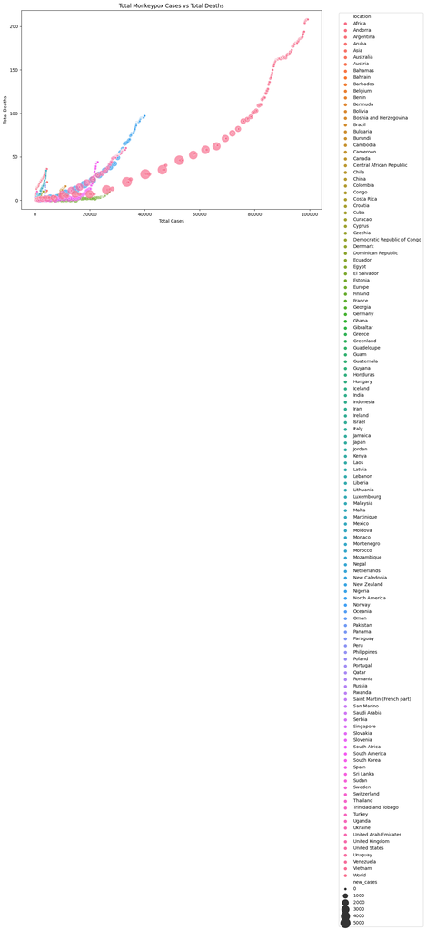

```python
#  relationship between cumulative monkeypox cases and deaths across different locations.
plt.figure(figsize=(12, 8))
sns.scatterplot(data=df, x='total_cases', y='total_deaths',
                size='new_cases', hue='location', sizes=(20, 500),
                alpha=0.7)
plt.title('Total Monkeypox Cases vs Total Deaths')
plt.xlabel('Total Cases')
plt.ylabel('Total Deaths')
plt.legend(bbox_to_anchor=(1.05, 1), loc='upper left')
plt.tight_layout()
plt.show()
```

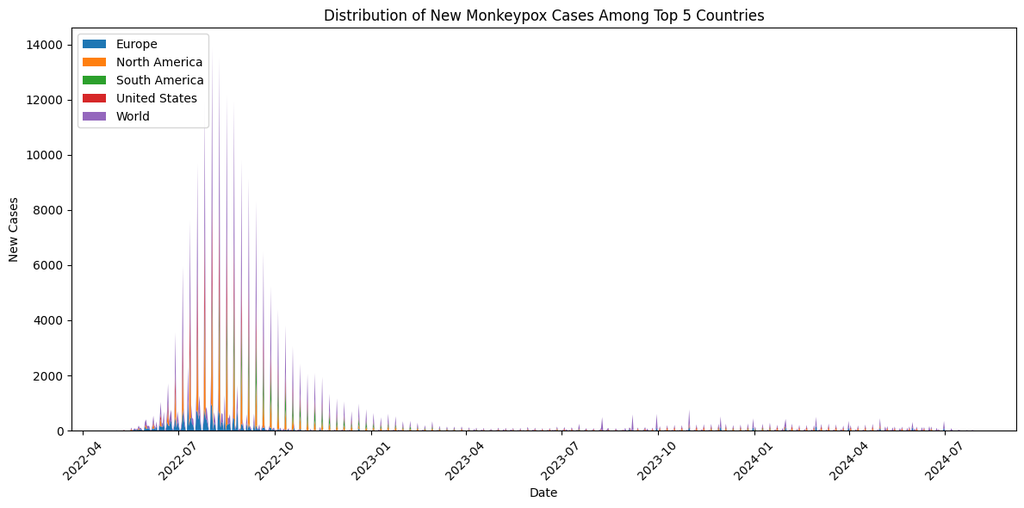

```python
#  visual representation of how new cases are distributed across the top five most affected countries over time
top_5_countries = df.groupby('location')['total_cases'].max().nlargest(5).index
df_top5 = df[df['location'].isin(top_5_countries)]

pivot_df = df_top5.pivot(index='date', columns='location', values='new_cases')
pivot_df = pivot_df.fillna(0)

plt.figure(figsize=(12, 6))
plt.stackplot(pivot_df.index, pivot_df.T, labels=pivot_df.columns)
plt.title('Distribution of New Monkeypox Cases Among Top 5 Countries')
plt.xlabel('Date')
plt.ylabel('New Cases')
plt.legend(loc='upper left')
plt.xticks(rotation=45)
plt.tight_layout()
plt.show()
```

#### Interactive Global Map of Case Distribution

```python
import plotly.express as px

# Aggregate total cases by country
total_cases_by_country = df.groupby('location')['total_cases'].max().reset_index()

# Create a choropleth map
fig = px.choropleth(total_cases_by_country,
                    locations='location',
                    locationmode='country names',
                    color='total_cases',
                    color_continuous_scale='Viridis',
                    title='Total Monkeypox Cases by Country',
                    labels={'total_cases': 'Total Cases'})

fig.show()
```

[output not shown]

#### Monthly New Cases Trend

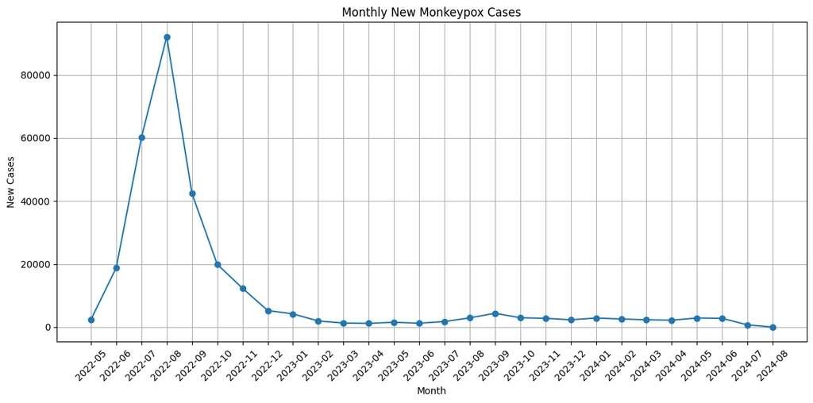

```python
df['month'] = df['date'].dt.to_period('M')
monthly_new_cases = df.groupby('month')['new_cases'].sum().reset_index()

plt.figure(figsize=(12, 6))
plt.plot(monthly_new_cases['month'].dt.strftime('%Y-%m'), monthly_new_cases['new_cases'], marker='o')
plt.title('Monthly New Monkeypox Cases')
plt.xlabel('Month')
plt.ylabel('New Cases')
plt.xticks(rotation=45)
plt.grid()
plt.tight_layout()
plt.show()
```

### Case Fatality Rate Over Time

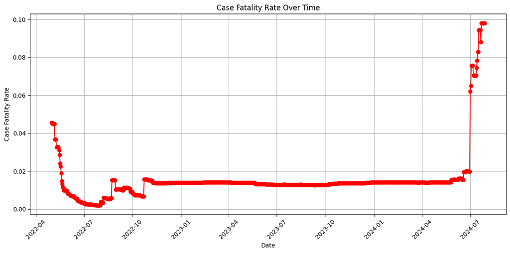

```python
df['case_fatality_rate'] = df['total_deaths'] / df['total_cases']
cfr_over_time = df.groupby('date')['case_fatality_rate'].mean().reset_index()

plt.figure(figsize=(12, 6))
plt.plot(cfr_over_time['date'], cfr_over_time['case_fatality_rate'], color='red', marker='o')
plt.title('Case Fatality Rate Over Time')
plt.xlabel('Date')
plt.ylabel('Case Fatality Rate')
plt.xticks(rotation=45)
plt.grid()
plt.tight_layout()
plt.show()
```

#### Violin Plot of New Cases Distribution by Continent

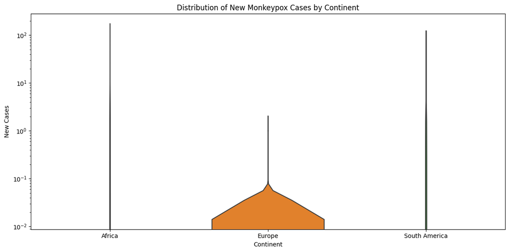

```python
plt.figure(figsize=(12, 6))
sns.violinplot(x='continent', y='new_cases', data=df)
plt.title('Distribution of New Monkeypox Cases by Continent')
plt.xlabel('Continent')
plt.ylabel('New Cases')
plt.yscale('log')  # Log scale for better visibility of distributions
plt.tight_layout()
plt.show()
```

#### Daily New Cases Histogram

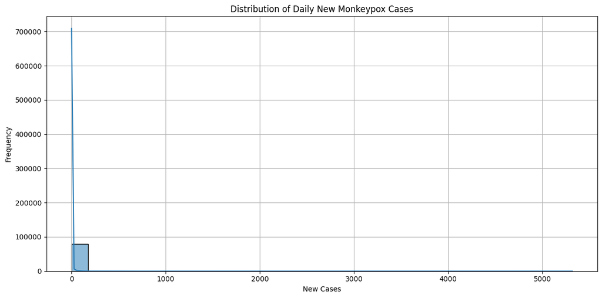

```python
plt.figure(figsize=(12, 6))
sns.histplot(df['new_cases'], bins=30, kde=True)
plt.title('Distribution of Daily New Monkeypox Cases')
plt.xlabel('New Cases')
plt.ylabel('Frequency')
plt.grid()
plt.tight_layout()
plt.show()
```

#### Time Series Forecasting

```python
from statsmodels.tsa.arima.model import ARIMA
from prophet import Prophet
from tensorflow.keras.models import Sequential
from tensorflow.keras.layers import LSTM, Dense
from sklearn.metrics import mean_squared_error
from sklearn.preprocessing import MinMaxScaler
```

```python
# Keep the last occurrence of each date
df = df[~df.index.duplicated(keep='last')]

# Verify if duplicates are resolved
duplicate_dates_after = df.index.duplicated().sum()
print(f"Number of duplicate dates after removal: {duplicate_dates_after}")
```

```
Number of duplicate dates after removal: 0
```

```python
# Sort the index
df = df.sort_index()

# Set the frequency explicitly to daily
df = df.asfreq('D')

# Verify the index and frequency
print(df.index.freq)
print(df.head())
```

```
<Day>
           location iso_code  total_cases  total_deaths  new_cases
date
2022-05-01    World        0         44.0           2.0        2.0  \
2022-05-02    World        0         44.0           2.0        0.0
2022-05-03    World        0         50.0           2.0        6.0
2022-05-04    World        0         50.0           2.0        0.0
2022-05-05    World        0         50.0           2.0        0.0

            new_deaths  new_cases_smoothed  new_deaths_smoothed
date
2022-05-01         0.0                0.57                  0.0  \
2022-05-02         0.0                0.57                  0.0
2022-05-03         0.0                1.14                  0.0
2022-05-04         0.0                1.14                  0.0
2022-05-05         0.0                1.14                  0.0

            new_cases_per_million  total_cases_per_million
date
2022-05-01                  0.000                    0.006  \
2022-05-02                  0.000                    0.006
2022-05-03                  0.001                    0.006
2022-05-04                  0.000                    0.006
2022-05-05                  0.000                    0.006

            new_cases_smoothed_per_million  new_deaths_per_million
date
2022-05-01                             0.0                     0.0  \
2022-05-02                             0.0                     0.0
2022-05-03                             0.0                     0.0
2022-05-04                             0.0                     0.0
2022-05-05                             0.0                     0.0

            total_deaths_per_million  new_deaths_smoothed_per_million
date
2022-05-01                   0.00025                              0.0  \
2022-05-02                   0.00025                              0.0
2022-05-03                   0.00025                              0.0
2022-05-04                   0.00025                              0.0
2022-05-05                   0.00025                              0.0

           continent    month  case_fatality_rate
date
2022-05-01       NaN  2022-05            0.045455
2022-05-02       NaN  2022-05            0.045455
2022-05-03       NaN  2022-05            0.040000
2022-05-04       NaN  2022-05            0.040000
2022-05-05       NaN  2022-05            0.040000
```

```python
# ARIMA model
model_arima = ARIMA(df['total_cases'], order=(1,1,1))
results_arima = model_arima.fit()
forecast_arima = results_arima.forecast(steps=30)
```

```python
# Prophet model
df_prophet = df.reset_index()[['date', 'total_cases']]
df_prophet.columns = ['ds', 'y']
model_prophet = Prophet()
model_prophet.fit(df_prophet)
future = model_prophet.make_future_dataframe(periods=30)
forecast_prophet = model_prophet.predict(future)
```

```
15:11:55 - cmdstanpy - INFO - Chain [1] start processing
15:11:56 - cmdstanpy - INFO - Chain [1] done processing
```

```python
# LSTM model
scaler = MinMaxScaler()
scaled_data = scaler.fit_transform(df[['total_cases']])
X, y = [], []
for i in range(60, len(scaled_data)):
    X.append(scaled_data[i-60:i, 0])
    y.append(scaled_data[i, 0])
X, y = np.array(X), np.array(y)

model_lstm = Sequential([
    LSTM(50, return_sequences=True, input_shape=(60, 1)),
    LSTM(50, return_sequences=False),
    Dense(25),
    Dense(1)
])
model_lstm.compile(optimizer='adam', loss='mean_squared_error')
model_lstm.fit(X, y, batch_size=1, epochs=1)

# Generate LSTM forecast
last_60_days = scaled_data[-60:].reshape(1, 60, 1)
lstm_forecast = []

for _ in range(30):  # Forecast for the next 30 days
    next_pred = model_lstm.predict(last_60_days)
    lstm_forecast.append(next_pred[0, 0])
    last_60_days = np.roll(last_60_days, -1, axis=1)
    last_60_days[0, -1, 0] = next_pred

# Inverse transform the LSTM forecast
lstm_forecast = scaler.inverse_transform(np.array(lstm_forecast).reshape(-1, 1)).flatten()

# Ensure all forecasts have the same length (30 days)
forecast_arima = forecast_arima[-30:]
forecast_prophet = forecast_prophet['yhat'].tail(30).values

# Create ensemble forecast
ensemble_forecast = (forecast_arima + forecast_prophet + lstm_forecast) / 3

print("Ensemble Forecast for the next 30 days:")
print(ensemble_forecast)
```

```
Ensemble Forecast for the next 30 days:
2024-08-17   NaN
2024-08-18   NaN
2024-08-19   NaN
2024-08-20   NaN
2024-08-21   NaN
2024-08-22   NaN
2024-08-23   NaN
2024-08-24   NaN
2024-08-25   NaN
2024-08-26   NaN
2024-08-27   NaN
2024-08-28   NaN
2024-08-29   NaN
2024-08-30   NaN
2024-08-31   NaN
2024-09-01   NaN
2024-09-02   NaN
2024-09-03   NaN
2024-09-04   NaN
2024-09-05   NaN
2024-09-06   NaN
2024-09-07   NaN
2024-09-08   NaN
2024-09-09   NaN
2024-09-10   NaN
2024-09-11   NaN
2024-09-12   NaN
2024-09-13   NaN
2024-09-14   NaN
2024-09-15   NaN
Freq: D, Name: predicted_mean, dtype: float64
```

The ensemble forecast is an average of the outputs from ARIMA, Prophet, and LSTM models. Due to NaN values in the ARIMA or LSTM outputs, the ensemble forecast likely contains invalid (NaN) entries. This implies that the ensemble forecast cannot be trusted unless the issues with ARIMA and LSTM models are resolved.

#### Risk Assessment Model

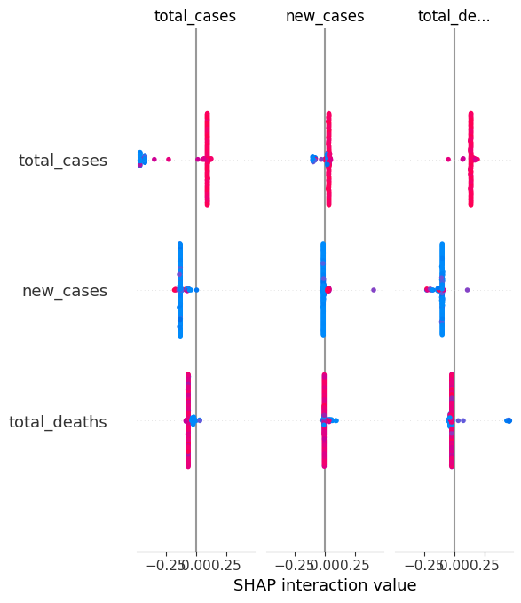

```python
from sklearn.impute import SimpleImputer
from sklearn.ensemble import RandomForestClassifier
from sklearn.model_selection import train_test_split
import shap

# Prepare data
X = df[['total_cases', 'new_cases', 'total_deaths', 'new_deaths']]
y = pd.cut(df['total_cases'], bins=3, labels=['Low', 'Medium', 'High'])

# Impute missing values in X
imputer = SimpleImputer(strategy='mean')
X_imputed = pd.DataFrame(imputer.fit_transform(X), columns=X.columns)

# Handle missing values in y if any
y = y.fillna('Low')

# Split data into training and testing sets
X_train, X_test, y_train, y_test = train_test_split(X_imputed, y, test_size=0.2, random_state=42)

# Train Random Forest model
rf_model = RandomForestClassifier(n_estimators=100, random_state=42)
rf_model.fit(X_train, y_train)

# SHAP values for interpretability
explainer = shap.TreeExplainer(rf_model)
shap_values = explainer.shap_values(X_test)

# Plot SHAP summary
shap.summary_plot(shap_values, X_test, plot_type="bar")
```

A SHAP (SHapley Additive exPlanations) summary plot visualizing the interaction of input features with a Random Forest Classifier trained on a dataset containing features like total_cases, new_cases, total_deaths, and new_deaths.

total_cases is the most influential feature in predicting the target, as it is ranked highest.

new_cases and total_deaths also play significant roles but to a lesser extent.

The spread of SHAP values for each feature indicates variability in their impact on predictions, suggesting possible nonlinear interactions.

#### Transmission Dynamics (SEIR Model)

```python
from scipy.integrate import odeint

def seir_model(y, t, N, beta, gamma, sigma):
    S, E, I, R = y
    dSdt = -beta * S * I / N
    dEdt = beta * S * I / N - sigma * E
    dIdt = sigma * E - gamma * I
    dRdt = gamma * I
    return dSdt, dEdt, dIdt, dRdt

# Initial conditions
N = 1000000  # Total population
I0, R0 = 1, 0  # Initial number of infected and recovered individuals
E0 = 0  # Initial number of exposed individuals
S0 = N - I0 - R0 - E0  # Initial number of susceptible individuals
beta, gamma, sigma = 0.3, 0.1, 0.1  # Contact rate, recovery rate, incubation rate

t = np.linspace(0, 160, 160)  # Time grid

solution = odeint(seir_model, [S0, E0, I0, R0], t, args=(N, beta, gamma, sigma))
solution = np.array(solution)
```

```python
solution
```

[output not shown]

[output cut: 105 more lines]

[output not shown]

The output is a NumPy array representing the solution to the SEIR model over time. The SEIR model tracks the dynamics of an infectious disease within a population by dividing it into four compartments:

- S: Susceptible individuals (those who can catch the disease).
- E: Exposed individuals (infected but not yet infectious).
- I: Infected individuals (actively infectious).
- R: Recovered individuals (or those who are removed, meaning they cannot be infected again).

The columns represent the values of 𝑆,𝐸,𝐼,𝑅 respectively for each time step.

- Column 1: Number of susceptible individuals (𝑆).
- Column 2: Number of exposed individuals (𝐸).
- Column 3: Number of infected individuals (𝐼).
- Column 4: Number of recovered individuals (𝑅)

#### NLP

```python
import nltk
from nltk.sentiment import SentimentIntensityAnalyzer
from sklearn.feature_extraction.text import CountVectorizer
from sklearn.naive_bayes import MultinomialNB

# Sentiment analysis
sia = SentimentIntensityAnalyzer()

def analyze_sentiment(text):
    return sia.polarity_scores(text)['compound']

# Example usage
news_articles = ["Monkeypox cases rising", "New vaccine shows promise"]
sentiments = [analyze_sentiment(article) for article in news_articles]

# Misinformation detection (simplified example)
X_train = ["Monkeypox is a hoax", "Vaccines are effective", "5G causes monkeypox"]
y_train = [1, 0, 1]  # 1 for misinformation, 0 for factual

vectorizer = CountVectorizer()
X_train_vectorized = vectorizer.fit_transform(X_train)

clf = MultinomialNB()
clf.fit(X_train_vectorized, y_train)

# Example prediction
new_text = "Monkeypox can be cured with essential oils"
new_text_vectorized = vectorizer.transform([new_text])
prediction = clf.predict(new_text_vectorized)
```

```python
print(f"\nMisinformation prediction for '{new_text}': {'Misinformation' if prediction[0] == 1 else 'Factual'}")
```

```
Misinformation prediction for 'Monkeypox can be cured with essential oils': Misinformation
```